# Chapter 21 Meta-Analysis | Chapter 28 Simulation Models

Qianqian Shan

June 11, 2017

# Chapter 21 Meta-Analysis

The systematic review of a body of evidence is know as **meta-analysis**.

Remove as much as possible of the subjectivity that was such a feature of old-fashioned narrative reviews.

*The data used for this Chapter was NOT found*.

# Chapter 28 Simulation models

For temporal dynamics, we may interested in:

- the transient dynamics(the behavior after the start but before the equilibrium is attained)
- equilibrium behavior (after the transients have damped away)
- chaos(random-looking, but actually deterministic temporal dynamics that are extremely sensitive to intial conditions)

For spatial dynmanics, we may interested in:

- metapopulation dynamics(where local extinction and recolonization of patches characterize the long-term behavior, with constant turnover of occupied patches)
- neighbor relations (in spatially explicit systems where the performance of individuals is determined by the identity and attributes of their immediate neighbors)
- pattern generation (dynamical process that lead to the generation of emergent, but more or less coherent patterns)

## Temporal dynamics: Chaotic dynamics in population size

**Quadratic map** is know as the simples density-dependent model of population dynamics.

$N(t+1) = \lambda N(t) [1-N(t)]$, where $N(t) is the population size at time t$.

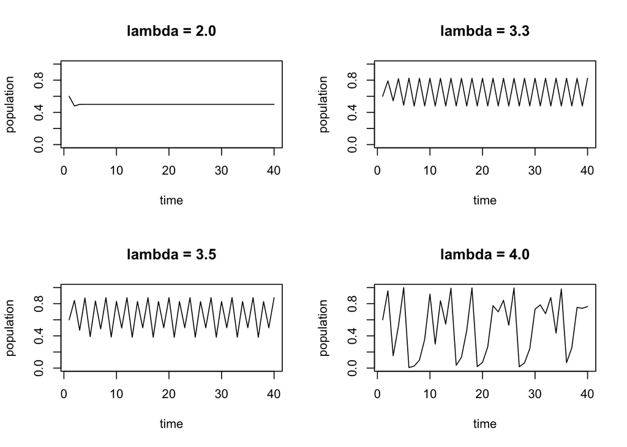

```r
# estimate the behavior of the quadratic map at different lambda values.


par(mfrow = c(2, 2))
lambda <- 2
x <- numeric(40)
x[1] <- 0.6
for (t in 2 : 40) x[t] <- lambda * x[t - 1] * (1 - x[t - 1])
plot(1:40, x, type = "l", ylim = c(0, 1), ylab = "population",
     xlab = "time", main = "lambda = 2.0")


lambda <- 3.3
x <- numeric(40)
x[1] <- 0.6
for (t in 2 : 40) x[t] <- lambda * x[t - 1] * (1 - x[t - 1])
plot(1:40, x, type = "l", ylim = c(0, 1), ylab = "population",
     xlab = "time", main = "lambda = 3.3")


lambda <- 3.5
x <- numeric(40)
x[1] <- 0.6
for (t in 2 : 40) x[t] <- lambda * x[t - 1] * (1 - x[t - 1])
plot(1:40, x, type = "l", ylim = c(0, 1), ylab = "population",
     xlab = "time", main = "lambda = 3.5")


lambda <- 4
x <- numeric(40)
x[1] <- 0.6
for (t in 2 : 40) x[t] <- lambda * x[t - 1] * (1 - x[t - 1])
plot(1:40, x, type = "l", ylim = c(0, 1), ylab = "population",
     xlab = "time", main = "lambda = 4.0")
```

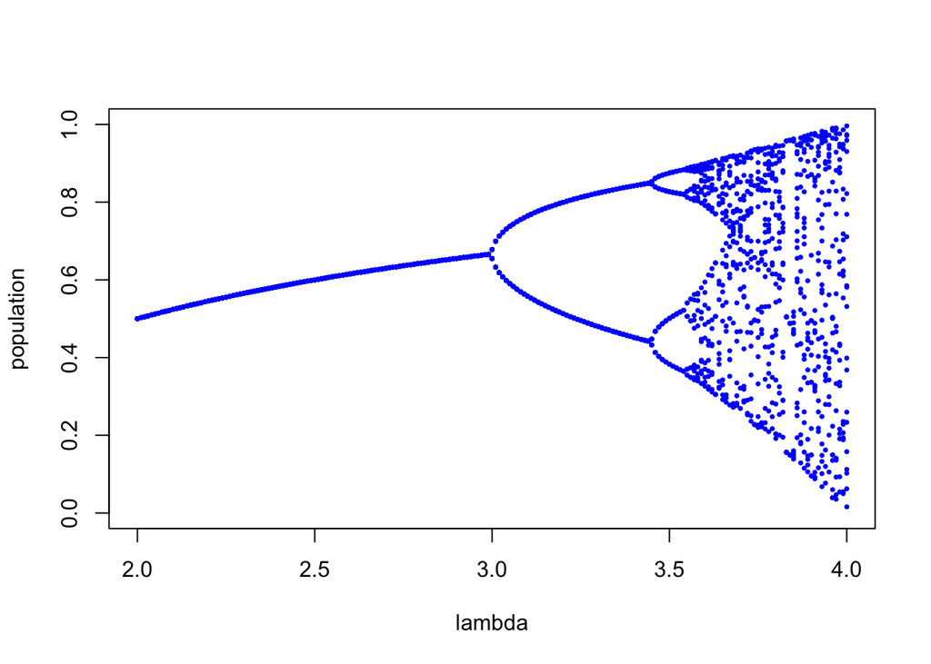

```r
par(mfrow = c(1, 1))



# investigate the route to chaoes


# a function to describe the dynamics as a function of lambda
numbers <- function(lambda) {
x <- numeric(400)
x[1] <- 0.6
for (t in 2 : 400) x[t] <- lambda * x[t-1] * (1 - x[t-1])
x[381:400] # extract the last 20 so any transients have died aways
}


par(mfrow = c(1, 1))
plot(c(2, 4), c(0, 1), type = "n", xlab = "lambda", ylab = "population")

for(lam in seq(2, 4, 0.01)) points(rep(lam, 20), sapply(lam, numbers), pch = 16, cex = 0.5, col = "blue")
```

```r
# the period-doubling route to chaos
```

## Temporal and spatial dynamics: a simulated random walk in two dimensions

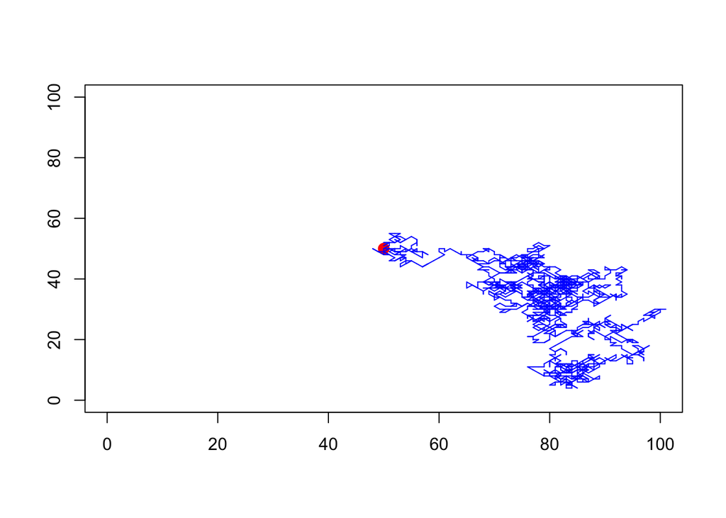

```r
# two-dim random walk starting from (50, 50)
plot(0:100, 0:100, type = "n", xlab = "", ylab = "")
x <- y <- 50
points(50, 50, pch = 16, col = "red", cex = 1.5)


for (i in 1:10000){
xi <- sample(c(1, 0, -1), 1)
yi <- sample(c(1, 0, -1), 1)
lines(c(x, x + xi), c(y, y + yi), col = "blue")
x <- x + xi
y <- y + yi
if(x > 100 | x < 0 | y > 100 | y < 0) break
}
```

## Spatial simulation models

Response variable is $p$, the proportion of patches occupied.

The dynamics of $p$, $\frac{dp}{dt} = p(1-p)m - ep$, and the equilibrium proportion of the occupied patches is $p^\ast = 1- \frac{e}{m}$ with $\frac{dp}{dt} = 0$.

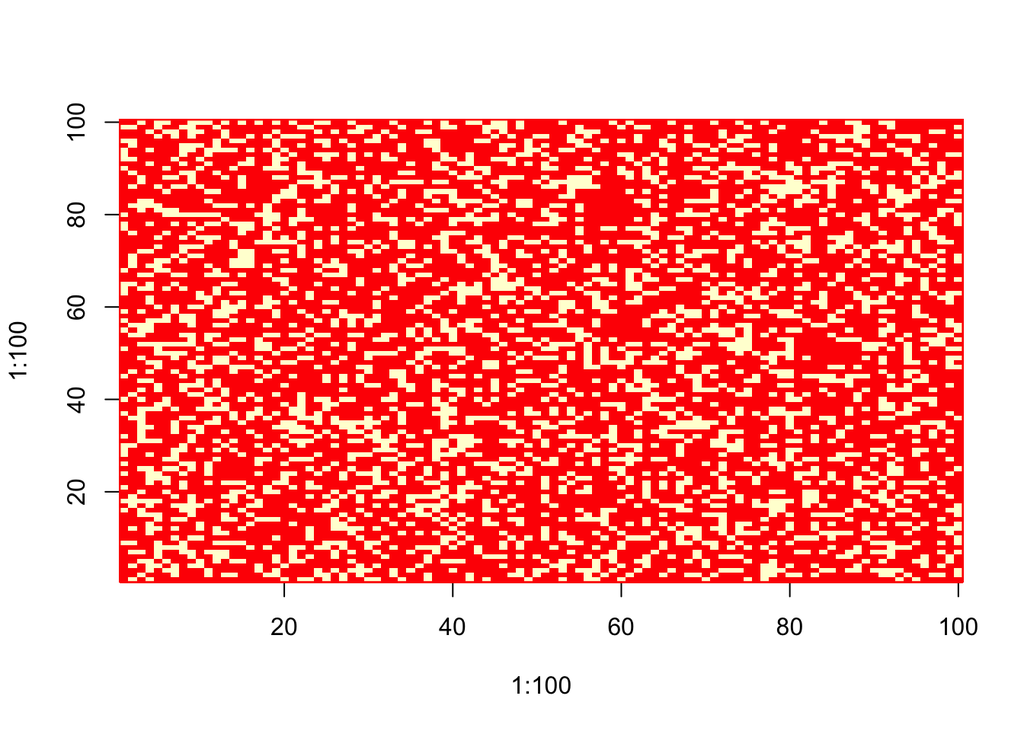

```r
# set parameter values
m <- 0.15
e <- 0.1


# initial conditions, placing occupied 100 patches at random in a sea of #unoccupied patches
s <- (1 - e)
N <- matrix(rep(0, 10000), nrow = 100)
xs <- sample(1:100)
ys <- sample(1:100)
for (i in 1:100){
N[xs[i], ys[i]] <- 1 }
image(1:100, 1:100, N) # colors corresponding to N


for (t in 1:1000){
S  <- matrix(runif(10000), nrow=100)
N <- N * (S < s)

im <- floor(sum(N * m))

placed <- matrix(sample(c(rep(1, im) , rep(0, 10000 - im))), nrow = 100)
N <- N + placed
N <- apply(N, 2, function(x) ifelse(x > 1, 1, x))
image(1:100, 1:100, N, add = TRUE)
box(col="red")
}
```

```r
# proportion of occupancy
sum(N)/length(N)
```

```
## [1] 0.3034
```

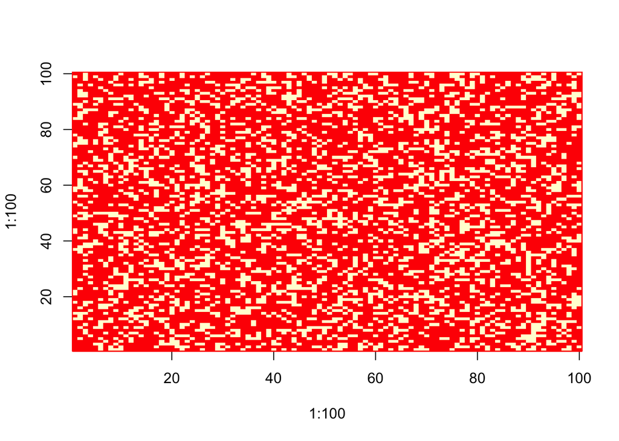

```r
m <- 0.15
e <- 0.1
s <- (1 - e)
N <- matrix(rep(0, 10000), nrow = 100)
xs <- sample(1:100)
ys <- sample(1:100)
for (i in 1:100){
N[xs[i], ys[i]] <- 1
}

image(1:100, 1:100, N)
for (t in 1:1000){
S <- matrix(runif(10000), nrow = 100)
N <- N*(S<s)

im <- floor(sum(N * m))
placed <- matrix(sample(c(rep(1, im) , rep(0, 10000 - im))), nrow = 100)
N <- N + placed
N <- apply(N, 2, function(x) ifelse(x > 1, 1, x))
image(1:100, 1:100, N, add = TRUE)
box(col = "red")
}
```

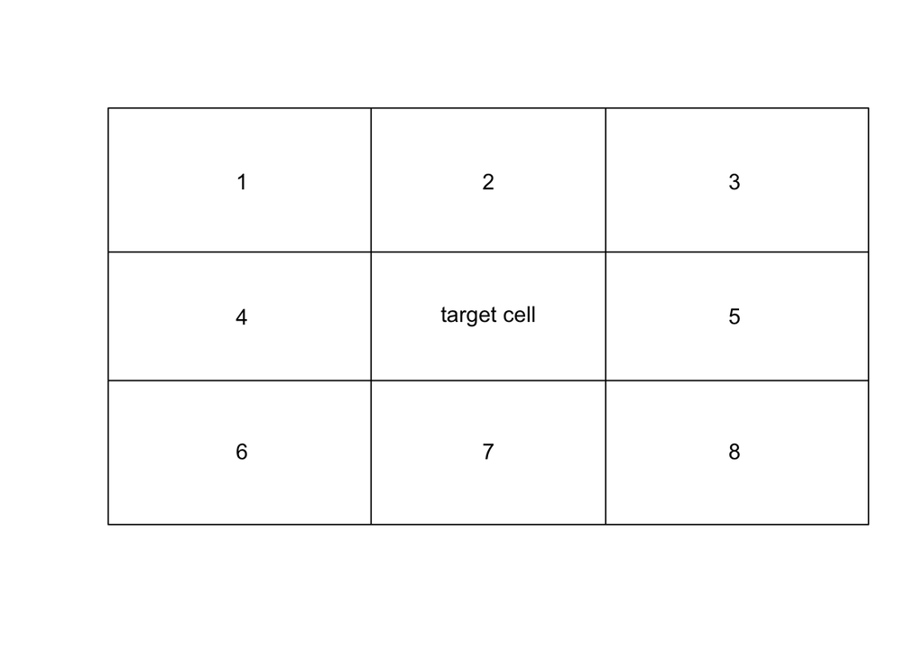

```r
# define neighbours
plot(c(0, 1), c(0, 1), xaxt = "n", yaxt = "n", type = "n", xlab = "", ylab = "")
abline("v" = c(1/3, 2/3))
abline("h"=c(1/3, 2/3))
xs <- c(.15, .5, .85, .15, .85, .15, .5, .85)
ys <- c(.85, .85, .85, .5, .5, .15, .15, .15)
for (i in 1:8) text(xs[i], ys[i], as.character(i))
text(.5, .5, "target cell")
```

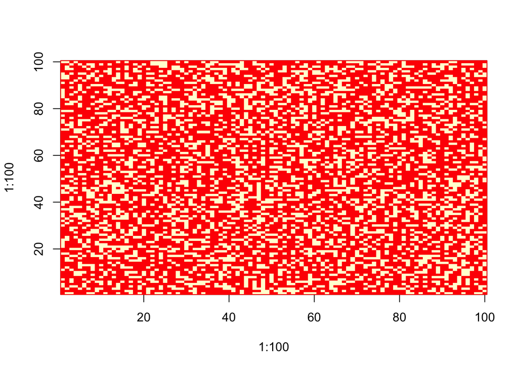

```r
# function to define the margins for the cells on the top, bottom, edge...
margins <- function(N){
edges <- matrix(rep(0,10404), nrow = 102)
edges[2:101, 2:101] <- N
edges[1, 2:101] <- N[100, ]
edges[102, 2:101] <- N[1, ]
edges[2:101, 1] <- N[, 100]
edges[2:101, 102] <- N[, 1]
edges[1, 1] <- N[100, 100]
edges[102, 102] <- N[1, 1]
edges[1, 102] <- N[100, 1]
edges[102, 1] <- N[1, 100]
edges
}

# function to count the number of species A in the eight neighbor cells
nhood <- function(X,j,i) sum(X[(j-1):(j+1), (i-1):(i+1)] == 1)

Ra <- 3
Rb <- 2.0
D <- 0.25
s <- (1-D)
T <- 6

# initial conditions
N <- matrix(c(rep(1, 5000), rep(2, 5000)), nrow = 100)
image(1:100, 1:100, N)



# simulation
for (t in 1:1000) {
S  <- 1 * (matrix(runif(10000), nrow = 100) < s)
N <- N * S
space <- 10000 - sum(S)
nt <- margins(N)
tots <- matrix(rep(0, 10000), nrow = 100)
for (a in 2:101) {
for (b in 2:101) {
tots[a-1, b-1] <- nhood(nt, a, b)
}
  }

# the survivors produce the seeds
seedsA <-  sum(N == 1) * Ra
seedsB <-  sum(N == 2) * Rb
all.seeds <- seedsA + seedsB
fA <- seedsA/all.seeds
fB <- 1 - fA


setA <- ceiling(10000 * fA)
placed <- matrix(sample(c(rep(1, setA), rep(2, 10000 - setA))), nrow = 100)


for (i in 1:100){
for(j in 1:100){
if (N[i, j] == 0 )
  if(placed[i, j] == 2) N[i, j] <- 2
  else if (tots[i, j] >= T) N[i, j] <- 2
  else N[i, j] <- 1
}
  }

image(1:100, 1:100, N, add = TRUE)
}
box(col="red")
```

## Pattern generation resulting from dynamic interactions

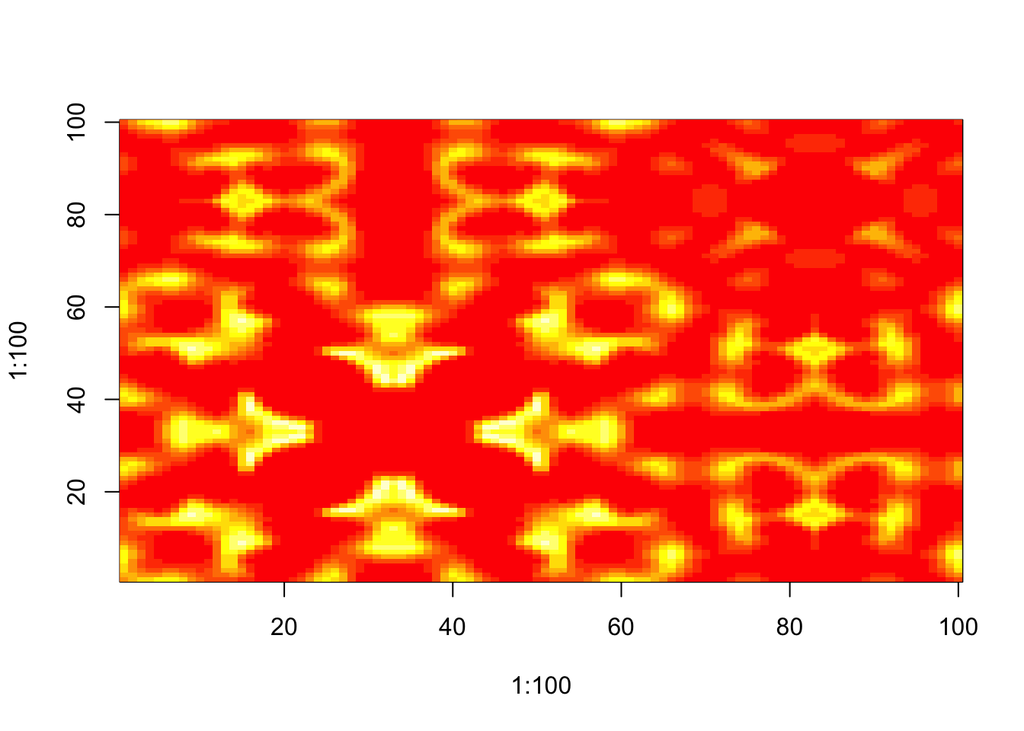

```r
r <- 0.4
a <- 0.1
Hmr <- 0.1
Pmr <- 0.9


N <- matrix(rep(0, 10000), nrow = 100)
P <- matrix(rep(0, 10000), nrow = 100)


N[33, 33] <- 200
P[33, 33] <- 100
image(1:100, 1:100, N)


host <- function(N, P) N * exp(r - a * P)
parasite <- function(N, P) N * (1 - exp(- a * P))

host.edges <- function(N){
Hedges <- matrix(rep(0, 10404), nrow = 102)
Hedges[2:101, 2:101] <- N
Hedges[1, 2:101] <- N[100, ]
Hedges[102, 2:101] <- N[1, ]
Hedges[2:101, 1] <- N[, 100]
Hedges[2:101, 102] <- N[ , 1]
Hedges[1, 1] <- N[100, 100]
Hedges[102, 102] <- N[1, 1]
Hedges[1, 102] <- N[100, 1]
Hedges[102, 1] <- N[1, 100]
Hedges
}

parasite.edges <- function(P){
  Pedges <- matrix(rep(0, 10404), nrow = 102)
Pedges[2:101, 2:101] <- P
Pedges[1, 2:101] <- P[100, ]
Pedges[102, 2:101] <- P[1, ]
Pedges[2:101, 1] <- P[, 100]
Pedges[2:101, 102] <- P[, 1]
Pedges[1, 1] <- P[100, 100]
Pedges[102, 102] <- P[1, 1]
Pedges[1, 102] <- P[100, 1]
Pedges[102, 1] <- P[1, 100]
Pedges
}



nhood <- function(X, j, i) sum(X[(j-1):(j+1), (i-1):(i+1)])

h.migration <- function(Hedges){
Hmigs <- matrix(rep(0, 10000), nrow = 100)
for (a in 2:101) {
for (b in 2:101) {
Hmigs[a-1, b-1] <- nhood(Hedges, a, b)
}
  }
Hmigs}


p.migration <- function(Pedges){
Pmigs <- matrix(rep(0, 10000), nrow = 100)
for (a in 2:101) {
for (b in 2:101) {
Pmigs[a - 1, b - 1] <- nhood(Pedges, a, b)
}
  }
Pmigs
}

for (t in 1:600){
he <- host.edges(N)
pe <- parasite.edges(P)
Hmigs <- h.migration(he)
Pmigs <- p.migration(pe)
N <- N - Hmr * N + Hmr * Hmigs/9
P <- P - Pmr * P + Pmr * Pmigs/9
Ni <- host(N, P)
P <- parasite(N, P)
N <- Ni
image(1:100, 1:100, N, add = TRUE) }
```